# Simulation and Plotting of Coverage Rates of Relative Risk and Odds Ratio for Wald-test and Adjust Wald-test

## 2.2 Figure2

Boxplots of coverage probabilities for nominal 95% adjusted confidence intervals based on adding t pseudo observations; distributions refer to 10,000 cases, with n 1 and n2 each chosen uniformly between 10 and 30 and p 1 and p2 chosen uniformly between 0 and 1.

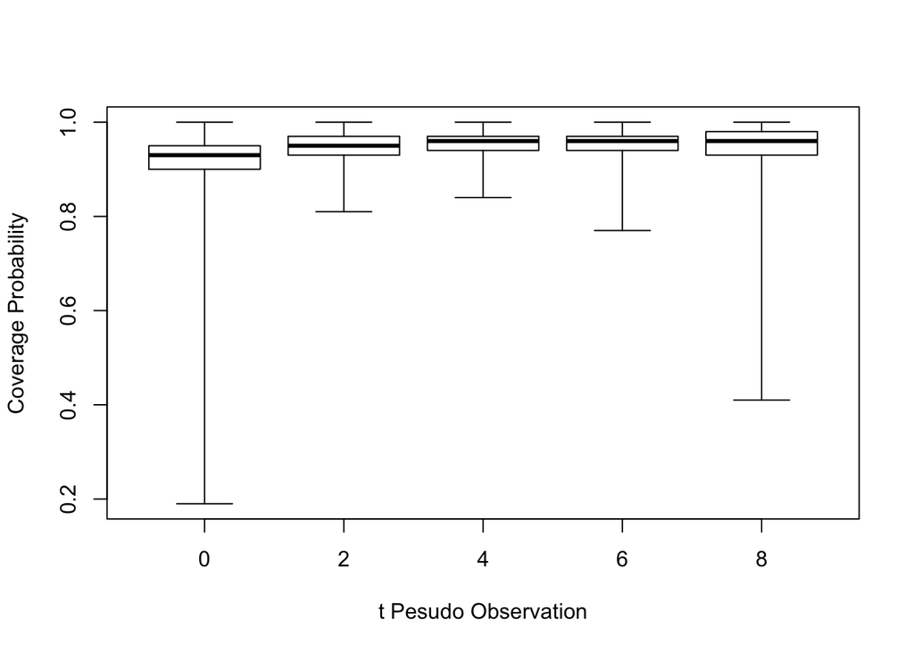

```r
Figure2 <- function(inter,n1,n2,p1,p2,alpha,t){

  x <- rbinom(inter,n1,p1)
  adj_est_p1 <- ( x+ t/4 ) / ( n1 + t/2 )

  y <- rbinom(inter,n2,p2)
  adj_est_p2 <- (  y+ t/4 ) / ( n2 + t/2 )


  se <- sqrt( adj_est_p1*(1-adj_est_p1)/n1 + adj_est_p2*(1-adj_est_p2)/n2 )


  adj_low <- (adj_est_p1- adj_est_p2) + qnorm(alpha/2,0,1) *
    sqrt(adj_est_p1*(1-adj_est_p1) / (n1+t/2) + adj_est_p2*(1-adj_est_p2)/(n2+t/2) )
  adj_up  <- (adj_est_p1- adj_est_p2) - qnorm(alpha/2,0,1) *
    sqrt(adj_est_p1*(1-adj_est_p1) / (n1+t/2) + adj_est_p2*(1-adj_est_p2)/(n2+t/2) )


  adj_cover <- length( which((p1- p2)<adj_up & (p1- p2)>adj_low) ) / inter

  return( adj_cover)
}



sim   <- 10000
t     <- seq(0,8,2)
cases <- matrix(NA,5,sim)
alpha <- 0.05

for (i in 1:length(t)) {
  for (j in 1:sim) {

    n1 <- sample(seq(10, 30, by=1),1)
    n2 <- sample(seq(10, 30, by=1),1)
    p1 <- runif(1,0,1)
    p2 <- runif(1,0,1)

    cases[i,j] <- Figure2(100, n1, n2, p1, p2, alpha, t[i])
  }
}

boxplot(cases~t,lty=1,ylab="Coverage Probability",xlab="t Pesudo Observation",range=0)
```

## 2.3 Figure 6

Coverage probabilities for nominal 95% Wald and adjusted confidence intervals (adding t = 4 pseudo observations) as a function of $p_1$ when $p_1-p_2 = 0$ or .2 and when $p_1/p_2= 2$ or 4, for $n_1 = n_2 = 10$.

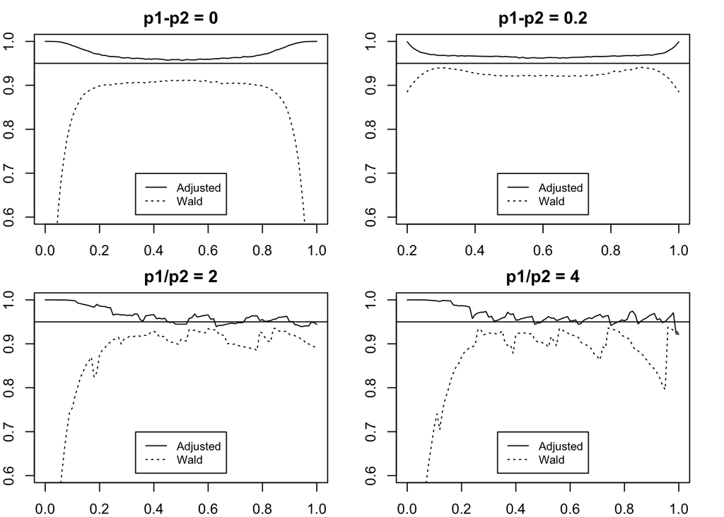

```r
# simultaion
rm(list = ls())
p1p2 <- function(inter,n1,n2,p1,p2,alpha,t){

  x          <- rbinom(inter,n1,p1)
  adj_est_p1 <- ( x+ t/4 ) / ( n1 + t/2 )
  wald_p1    <- x/n1

  y          <- rbinom(inter,n2,p2)
  adj_est_p2 <- (  y+ t/4 ) / ( n2 + t/2 )
  wald_p2    <- y/n2

  se  <- sqrt( adj_est_p1*(1-adj_est_p1)/n1 + adj_est_p2*(1-adj_est_p2)/n2 )
  se1 <- sqrt( wald_p1*(1-wald_p1)/n1 + wald_p2*(1-wald_p2)/n2 )


  adj_low <- (adj_est_p1- adj_est_p2) + qnorm(alpha/2,0,1) *
    sqrt(adj_est_p1*(1-adj_est_p1)/(n1+t/2) + adj_est_p2*(1-adj_est_p2)/(n2+t/2) )
  adj_up  <- (adj_est_p1- adj_est_p2) - qnorm(alpha/2,0,1) *
    sqrt(adj_est_p1*(1-adj_est_p1)/(n1+t/2) + adj_est_p2*(1-adj_est_p2)/(n2+t/2) )

  wald_low <- (wald_p1- wald_p2) + qnorm(alpha/2,0,1) *
    sqrt(wald_p1*(1-wald_p1)/n1 + wald_p2*(1-wald_p2)/n2 )

  wald_up  <- (wald_p1- wald_p2) - qnorm(alpha/2,0,1) *
    sqrt(wald_p1*(1-wald_p1)/n1 + wald_p2*(1-wald_p2)/n2 )


  adj_cover  <- length( which((p1- p2)< adj_up  & (p1- p2) > adj_low) )/ inter
  wald_cover <- length( which((p1- p2)< wald_up & (p1- p2) > wald_low) )/ inter

  return( cbind(adj_cover, wald_cover) )
}


# Calculate the difference(p1-p2) from the simulation
plot_diff <- function(inter,n1,n2,alpha,t,diff,ratio){

  p1         <- seq(diff,1,0.01)
  p2         <- p1-diff
  cover_adj  <- rep(NA,length(p1) )
  cover_wald <- rep(NA,length(p1))

  for (i in 1: length(p1) ) {

    cover_adj[i]  <- p1p2(inter,n1,n2,p1[i],p2[i],alpha,t)[,1]
    cover_wald[i] <- p1p2(inter,n1,n2,p1[i],p2[i],alpha,t)[,2]

  }

  txt_diff <- paste("p1-p2 =", diff)

  plot(p1, cover_adj, type="l", lty=1, ylim=c(0.6,1),
       xlim=c(min(p1), max(p1) ), ylab="Coverage Probability",xlab="P1" )
  lines(p1, cover_wald, type="l", lty=3, ylim=c(0.6,1),
        ylab="Coverage Probability", xlab="P1" )
  abline(h = 1-alpha)
  title(main = txt_diff)
  legend("bottom", legend = c("Adjusted","Wald"), lty = c(1,3), cex=0.8, inset=0.05)

  }


# Calculate the ratio(p1/p2) from the simulation
plot_ratio <- function(inter,n1,n2,alpha,t,ratio){
  p1         <- seq(0,1,0.01)
  p2         <- p1/ratio
  cover_adj  <- rep(NA,length(p1) )
  cover_wald <- rep(NA,length(p1))

  for (i in 1: length(p1) ) {

    cover_adj[i]  <- p1p2(inter, n1, n2, p1[i], p2[i], alpha, t)[,1]
    cover_wald[i] <- p1p2(inter, n1, n2, p1[i], p2[i], alpha, t)[,2]

  }

  txt_ratio <- paste("p1/p2 =",ratio )

  plot(p1, cover_adj, type="l", lty=1, ylim=c(0.6,1),
       ylab="Coverage Probability", xlab="P1" )
  lines(p1, cover_wald, type="l", lty=3, ylim=c(0.6,1),
       ylab="Coverage Probability", xlab="P1")
  title(main = txt_ratio)
  abline(h = 1-alpha)
  legend("bottom", legend = c("Adjusted","Wald"), lty = c(1,3), cex=0.8, inset=0.05)
}



# loop the plot functions
ratio <- c(2,4)
diff  <- c(0,0.2)

par(mfcol=c(2,2))
par(mar=c(2,2,2,2))

for (i in 1:length(ratio)) {

  # plot_diff <- function(inter, n1, n2, alpha, t, diff, ratio)
  plot_diff(100000,10,10,0.05,4, diff[i])

  # plot_ratio <- function(inter, n1, n2, alpha, t, ratio)
  plot_ratio(100000,10,10,0.05,4, ratio[i])
}
```

```r
par(mfrow=c(1,1))
```

# III. Reference:

1. Agresti A., Caffo B. (2000) Simple and Effective Confidence Intervals for Proportions and Differences of Proportions. The American Statistician 54, 280-288.